# Analise descritiva de dados - Projeto detecção de drones intrusos

### Principais topicos

- Caracterizacao de dados:
- Tipo e escala
- Tipos de Dados
- Exploração de dados:
- Estatistica descritiva
- Captura de informacoes como: Frequência, Localizaçao ou tendência central, Dispersao ou espalhamento, Distribuicao ou formato
- Ferramentas de visualização (por ex.: Boxplots, Histogramas, Grafico de pizza, Scatter plots, Heatmaps ... )

# Analise 1 Unidirectional Flow: Dataset 4,5 e 6

```python
import pandas as pd
```

```python
lista = ['V1 size','V2 size','V3 size','V4 size','V5 size','V6 size','V7 size','V8 size','V9 size','V1 interv.','V2 interv.','V3 interv.','V4 interv.','V5 interv.','V6 interv.','V7 interv.','V8 interv.','V9 interv.','classe']
```

```python
#lista = ['Mean_uplink_size','Median_uplink_size','MAD_uplink_size','STD_uplink_size','Skewness_uplink_size','V6_uplink_size','V7_uplink_size','V8_uplink_size','V9_uplink_size','V1_uplink_interval','V2_uplink_interval','V3_uplink_interval','V4_uplink_interval','V5_uplink_interval','V6_uplink_interval','V7_uplink_interval','V8_uplink_interval','V9_uplink_interval','classe']
```

```python
df_test_4= pd.read_csv('dataset\dataset4_teste.csv', sep = ',', names=lista)
```

```python
df_test_5= pd.read_csv('dataset\dataset5_teste.csv', sep = ',', names=lista)
```

```python
df_test_6= pd.read_csv('dataset\dataset6_teste.csv', sep = ',', names=lista)
```

```python
df_train_4= pd.read_csv('dataset\dataset4_treino.csv', sep = ',', names=lista)
```

```python
df_train_5= pd.read_csv('dataset\dataset5_treino.csv', sep = ',', names=lista)
```

```python
df_train_6= pd.read_csv('dataset\dataset6_treino.csv', sep = ',', names=lista)
```

```python
print("Tamanho df teste 4 : ",len(df_test_4))
print("Tamanho df treino 4 : ",len(df_train_4))
print("Tamanho df teste 5 : ",len(df_test_5))
print("Tamanho df treino 5 : ",len(df_train_5))
print("Tamanho df teste 6 : ",len(df_test_6))
print("Tamanho df treino 6 : ", len(df_train_6))
```

```
Tamanho df teste 4 :  1063
Tamanho df treino 4 :  10600
Tamanho df teste 5 :  1351
Tamanho df treino 5 :  13513
Tamanho df teste 6 :  7
Tamanho df treino 6 :  66
```

## Concatenando os dataframes 4,5 e 6:

```python
frames = [df_train_4,df_test_4, df_train_5, df_test_5, df_train_6, df_test_6]
df_train1 = pd.concat(frames)
```

```python
len(df_train1)
```

```
26600
```

```python
df_train1.head()
```

|  | V1 size | V2 size | V3 size | V4 size | V5 size | V6 size | V7 size | V8 size | V9 size | V1 interv. | V2 interv. | V3 interv. | V4 interv. | V5 interv. | V6 interv. | V7 interv. | V8 interv. | V9 interv. | classe |
| --- | --- | --- | --- | --- | --- | --- | --- | --- | --- | --- | --- | --- | --- | --- | --- | --- | --- | --- | --- |
| 0 | 0.000438 | 0.002101 | 0.000006 | 0.000003 | 6.5008 | 42.76100 | 0.016319 | 0.000003 | 0.002136 | 759.62 | 477.050 | 1130.0 | 0.000 | -0.505190 | -1.74200 | 1130 | 61 | 895.730 | 1 |
| 1 | 0.000388 | 0.000783 | 0.000130 | 0.000090 | 2.4140 | 3.95440 | 0.002615 | 0.000000 | 0.000870 | 86.32 | 35.631 | 62.0 | 0.000 | 0.760200 | -1.43620 | 138 | 62 | 93.317 | 1 |
| 2 | 0.000142 | 0.000174 | 0.000100 | 0.000147 | 1.3829 | 0.91272 | 0.000585 | 0.000000 | 0.000224 | 103.47 | 40.320 | 138.0 | 22.239 | -0.036313 | -1.95700 | 153 | 62 | 110.970 | 1 |
| 3 | 0.000645 | 0.001331 | 0.000145 | 0.000073 | 3.9211 | 21.45700 | 0.009911 | 0.000007 | 0.001473 | 81.76 | 33.504 | 62.0 | 0.000 | 1.077900 | -0.84623 | 138 | 62 | 88.295 | 1 |
| 4 | 0.000171 | 0.000218 | 0.000127 | 0.000053 | 2.6358 | 6.42960 | 0.000961 | 0.000003 | 0.000277 | 86.32 | 35.631 | 62.0 | 0.000 | 0.760200 | -1.43620 | 138 | 62 | 93.317 | 1 |

### Substituindo 0 e 1 como Other e UAV

```python
df_train1['classe'] = df_train1['classe'].replace([1],'VANT')
```

```python
df_train1['classe'] = df_train1['classe'].replace([0],'Outro')
```

```python
df_train1.head()
```

|  | V1 size | V2 size | V3 size | V4 size | V5 size | V6 size | V7 size | V8 size | V9 size | V1 interv. | V2 interv. | V3 interv. | V4 interv. | V5 interv. | V6 interv. | V7 interv. | V8 interv. | V9 interv. | classe |
| --- | --- | --- | --- | --- | --- | --- | --- | --- | --- | --- | --- | --- | --- | --- | --- | --- | --- | --- | --- |
| 0 | 0.000438 | 0.002101 | 0.000006 | 0.000003 | 6.5008 | 42.76100 | 0.016319 | 0.000003 | 0.002136 | 759.62 | 477.050 | 1130.0 | 0.000 | -0.505190 | -1.74200 | 1130 | 61 | 895.730 | VANT |
| 1 | 0.000388 | 0.000783 | 0.000130 | 0.000090 | 2.4140 | 3.95440 | 0.002615 | 0.000000 | 0.000870 | 86.32 | 35.631 | 62.0 | 0.000 | 0.760200 | -1.43620 | 138 | 62 | 93.317 | VANT |
| 2 | 0.000142 | 0.000174 | 0.000100 | 0.000147 | 1.3829 | 0.91272 | 0.000585 | 0.000000 | 0.000224 | 103.47 | 40.320 | 138.0 | 22.239 | -0.036313 | -1.95700 | 153 | 62 | 110.970 | VANT |
| 3 | 0.000645 | 0.001331 | 0.000145 | 0.000073 | 3.9211 | 21.45700 | 0.009911 | 0.000007 | 0.001473 | 81.76 | 33.504 | 62.0 | 0.000 | 1.077900 | -0.84623 | 138 | 62 | 88.295 | VANT |
| 4 | 0.000171 | 0.000218 | 0.000127 | 0.000053 | 2.6358 | 6.42960 | 0.000961 | 0.000003 | 0.000277 | 86.32 | 35.631 | 62.0 | 0.000 | 0.760200 | -1.43620 | 138 | 62 | 93.317 | VANT |

## Analisando se existem campos vazios ou com NaN

```python
df_train1.isnull().values.any()
```

```
False
```

```python
df_train1.isnull().sum()
```

```
V1 size       0
V2 size       0
V3 size       0
V4 size       0
V5 size       0
V6 size       0
V7 size       0
V8 size       0
V9 size       0
V1 interv.    0
V2 interv.    0
V3 interv.    0
V4 interv.    0
V5 interv.    0
V6 interv.    0
V7 interv.    0
V8 interv.    0
V9 interv.    0
classe        0
dtype: int64
```

```python
print(df_train1.shape)
print(df_train1.dropna().shape)
```

```
(26600, 19)
(26600, 19)
```

### Podemos notar que não ha valores faltantes ou NaN

# Investigando o balanceamento dos dados

```python
import seaborn as sns
```

```python
df_train1.classe.value_counts(normalize=True).round(3)
```

```
VANT     0.533
Outro    0.467
Name: classe, dtype: float64
```

```python
targets= df_train1.classe.to_numpy()
```

```python
from collections import Counter
print(Counter(targets))
```

```
Counter({'VANT': 14171, 'Outro': 12429})
```

## Vemos que 53% dos objetos são do tipo UAV e 46,7% deles são não UAV

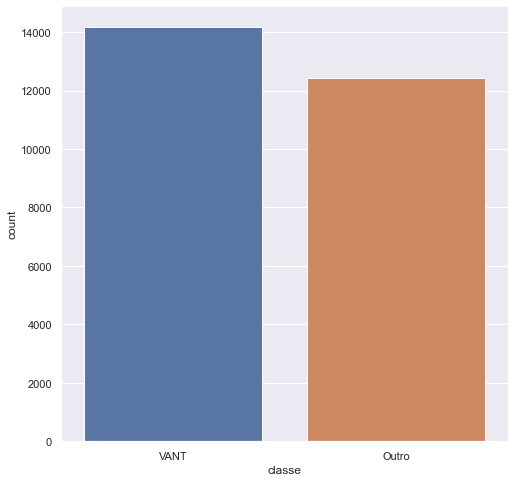

```python
import matplotlib.pyplot as plt
sns.set(font_scale=1.3)
sns.set(rc={'figure.figsize':(8,8)})
ax = sns.countplot(x="classe", data=df_train1)
fig = ax.get_figure()
fig.savefig("balanceamento_Datasets_456.png")
```

### Investigando dados estatisticos: médias, desvios padrão, quartis q1, q2 e q3, valores maximos, kurtose, obliquidade

```python
df_train1.describe().round(4)
```

|  | V1 size | V2 size | V3 size | V4 size | V5 size | V6 size | V7 size | V8 size | V9 size | V1 interv. | V2 interv. | V3 interv. | V4 interv. | V5 interv. | V6 interv. | V7 interv. | V8 interv. | V9 interv. |
| --- | --- | --- | --- | --- | --- | --- | --- | --- | --- | --- | --- | --- | --- | --- | --- | --- | --- | --- |
| count | 26600.0000 | 26600.0000 | 26600.0000 | 26600.0000 | 26600.0000 | 26600.0000 | 26600.0000 | 26600.0000 | 26600.0000 | 26600.0000 | 26600.0000 | 26600.0000 | 26600.000 | 26600.0000 | 26600.0000 | 26600.0000 | 26600.0000 | 26600.0000 |
| mean | 0.1413 | 0.8321 | 0.0092 | 0.0054 | 4.0116 | 23.1255 | 7.5087 | 0.0001 | 0.8450 | 746.7540 | 351.6730 | 863.5097 | 97.517 | -0.5053 | 4.6564 | 1121.2766 | 167.1006 | 842.8334 |
| std | 2.3531 | 21.3945 | 0.5917 | 0.0485 | 2.2606 | 23.7243 | 213.3520 | 0.0001 | 21.4168 | 514.2398 | 264.5077 | 657.7561 | 192.386 | 2.2341 | 14.1061 | 658.1798 | 151.6565 | 550.8321 |
| min | 0.0001 | 0.0000 | 0.0000 | 0.0000 | -1.9319 | -1.9807 | 0.0002 | 0.0000 | 0.0001 | 63.5200 | 0.2000 | 62.0000 | 0.000 | -9.7020 | -2.0199 | 68.0000 | 61.0000 | 63.9810 |
| 25% | 0.0013 | 0.0025 | 0.0001 | 0.0001 | 2.3231 | 5.7673 | 0.0166 | 0.0000 | 0.0029 | 123.1475 | 40.3760 | 138.0000 | 0.000 | -1.0159 | -1.2723 | 183.0000 | 76.0000 | 130.6400 |
| 50% | 0.0033 | 0.0082 | 0.0003 | 0.0002 | 3.4637 | 13.7380 | 0.0477 | 0.0000 | 0.0093 | 866.2550 | 359.4900 | 1166.0000 | 0.000 | -0.3316 | 1.1759 | 1502.0000 | 76.0000 | 1083.4000 |
| 75% | 0.0122 | 0.0267 | 0.0009 | 0.0008 | 5.4842 | 33.7100 | 0.1515 | 0.0001 | 0.0289 | 1141.1250 | 618.9500 | 1476.0000 | 112.680 | 0.5807 | 2.2490 | 1610.0000 | 222.0000 | 1285.5000 |
| max | 149.8700 | 1492.4000 | 68.1710 | 3.9419 | 9.8493 | 98.0100 | 14925.0000 | 0.0082 | 1492.5000 | 1675.7000 | 761.0700 | 1676.0000 | 1136.400 | 9.8494 | 98.0100 | 3468.0000 | 1676.0000 | 1675.7000 |

```python
df_train1.info()
```

```
<class 'pandas.core.frame.DataFrame'>
Int64Index: 26600 entries, 0 to 6
Data columns (total 19 columns):
 #   Column      Non-Null Count  Dtype
---  ------      --------------  -----
 0   V1 size     26600 non-null  float64
 1   V2 size     26600 non-null  float64
 2   V3 size     26600 non-null  float64
 3   V4 size     26600 non-null  float64
 4   V5 size     26600 non-null  float64
 5   V6 size     26600 non-null  float64
 6   V7 size     26600 non-null  float64
 7   V8 size     26600 non-null  float64
 8   V9 size     26600 non-null  float64
 9   V1 interv.  26600 non-null  float64
 10  V2 interv.  26600 non-null  float64
 11  V3 interv.  26600 non-null  float64
 12  V4 interv.  26600 non-null  float64
 13  V5 interv.  26600 non-null  float64
 14  V6 interv.  26600 non-null  float64
 15  V7 interv.  26600 non-null  int64
 16  V8 interv.  26600 non-null  int64
 17  V9 interv.  26600 non-null  float64
 18  classe      26600 non-null  object
dtypes: float64(16), int64(2), object(1)
memory usage: 4.6+ MB
```

```python
description = df_train1.describe().round(4)
```

```python
description.to_csv("my_description456linha.csv")
```

```python
df_train1.var()
```

```
V1 size       5.536965e+00
V2 size       4.577255e+02
V3 size       3.500920e-01
V4 size       2.351920e-03
V5 size       5.110250e+00
V6 size       5.628427e+02
V7 size       4.551910e+04
V8 size       2.030163e-08
V9 size       4.586790e+02
V1 interv.    2.644426e+05
V2 interv.    6.996434e+04
V3 interv.    4.326431e+05
V4 interv.    3.701237e+04
V5 interv.    4.990980e+00
V6 interv.    1.989807e+02
V7 interv.    4.332006e+05
V8 interv.    2.299970e+04
V9 interv.    3.034161e+05
dtype: float64
```

```python
skewness = df_train1.skew().round(4)
```

```python
df_train1.skew().round(4)
```

```
V1 size        42.3114
V2 size        48.1196
V3 size       114.9621
V4 size        47.2162
V5 size         0.7266
V6 size         1.3725
V7 size        48.4269
V8 size        20.7556
V9 size        48.0160
V1 interv.      0.0228
V2 interv.      0.0022
V3 interv.     -0.0752
V4 interv.      2.7070
V5 interv.     -0.8213
V6 interv.      4.4754
V7 interv.     -0.7094
V8 interv.      3.9658
V9 interv.     -0.2779
dtype: float64
```

```python
skewness.to_csv("skeness456linha.csv")
```

```python
df_train1.kurtosis()
```

```
V1 size        1986.326023
V2 size        2558.709610
V3 size       13242.331810
V4 size        3410.116712
V5 size          -0.218241
V6 size           1.012844
V7 size        2585.214505
V8 size         979.722630
V9 size        2549.394717
V1 interv.       -1.367117
V2 interv.       -1.614993
V3 interv.       -1.823425
V4 interv.        7.930638
V5 interv.        4.768366
V6 interv.       22.253497
V7 interv.       -1.405862
V8 interv.       24.735536
V9 interv.       -1.531201
dtype: float64
```

```python
kurts = df_train1.kurtosis()
```

```python
kurts.to_csv("kurtosis456.csv")
```

# Investigando correlações:

# I) Scatter plots

## Correlações uplink_size- uplink_interval

```python
y= df_train1.classe.to_numpy()
```

```python
y
```

```
array(['VANT', 'VANT', 'VANT', ..., 'VANT', 'VANT', 'VANT'], dtype=object)
```

```python
print(df_train1.keys())
```

```
Index(['V1 size', 'V2 size', 'V3 size', 'V4 size', 'V5 size', 'V6 size',
       'V7 size', 'V8 size', 'V9 size', 'V1 interv.', 'V2 interv.',
       'V3 interv.', 'V4 interv.', 'V5 interv.', 'V6 interv.', 'V7 interv.',
       'V8 interv.', 'V9 interv.', 'classe'],
      dtype='object')
```

## Uplink_size: Grafico Matriz de scatterplot

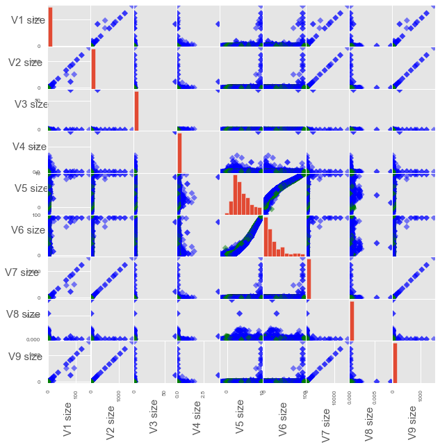

```python
import numpy as np

attributes = lista
attributes = attributes[0:9]

plt.style.use('ggplot')
colors_palette = {'Outro': 'blue', 'VANT': 'green'}
groups = list(y)
colors = [colors_palette[c] for c in groups]


axes = pd.plotting.scatter_matrix(df_train1[attributes],c=colors, figsize=(10, 10),s=40,marker='D')


#for ax in axes.flatten():
#    ax.xaxis.label.set_rotation(90)
#    ax.yaxis.label.set_rotation(0)
#    ax.yaxis.label.set_ha('right')

for ax in axes.ravel():
    ax.set_xlabel(ax.get_xlabel(), fontsize = 15, rotation = 90)
    ax.set_ylabel(ax.get_ylabel(), fontsize = 15, rotation = 0)

plt.savefig("ScatterMatrix1_Datasets_456.png")
```

# Uplink_interval

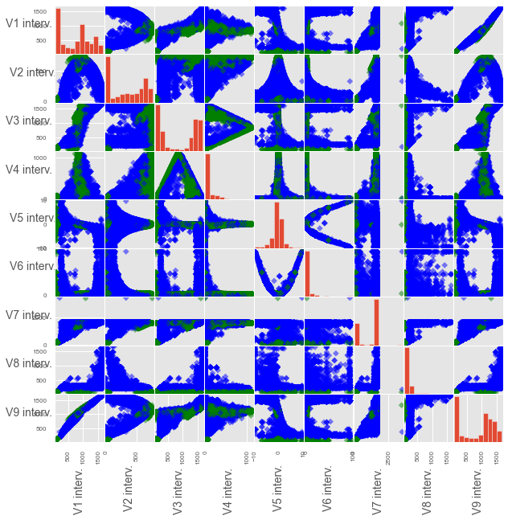

```python
attributes = lista
attributes = attributes[9:18]
plt.style.use('ggplot')
colors_palette = {'Outro': 'blue', 'VANT': 'green'}
groups = list(y)
colors = [colors_palette[c] for c in groups]

axes = pd.plotting.scatter_matrix(df_train1[attributes],c=colors,figsize=[10,10],s=30,marker='D')

#for ax in axes.flatten():
#    ax.xaxis.label.set_rotation(90)
#    ax.yaxis.label.set_rotation(0)
#    ax.yaxis.label.set_ha('right')

for ax in axes.ravel():
    ax.set_xlabel(ax.get_xlabel(), fontsize = 14, rotation = 90)
    ax.set_ylabel(ax.get_ylabel(), fontsize = 14, rotation = 0)

plt.savefig("ScatterMatrix3_Datasets_456.png")
```

## 2) Investigando correlações em Heatmaps

```python
df_train1['classe'] = df_train1['classe'].replace('VANT',1)
```

```python
df_train1['classe'] = df_train1['classe'].replace('Outro',0)
```

```python
y= df_train1.classe.to_numpy()
```

```python
#df_train1 = df_train1.drop(['classe'], axis=1)
```

```python
df_train1.head()
```

|  | V1 size | V2 size | V3 size | V4 size | V5 size | V6 size | V7 size | V8 size | V9 size | V1 interv. | V2 interv. | V3 interv. | V4 interv. | V5 interv. | V6 interv. | V7 interv. | V8 interv. | V9 interv. | classe |
| --- | --- | --- | --- | --- | --- | --- | --- | --- | --- | --- | --- | --- | --- | --- | --- | --- | --- | --- | --- |
| 0 | 0.000438 | 0.002101 | 0.000006 | 0.000003 | 6.5008 | 42.76100 | 0.016319 | 0.000003 | 0.002136 | 759.62 | 477.050 | 1130.0 | 0.000 | -0.505190 | -1.74200 | 1130 | 61 | 895.730 | 1 |
| 1 | 0.000388 | 0.000783 | 0.000130 | 0.000090 | 2.4140 | 3.95440 | 0.002615 | 0.000000 | 0.000870 | 86.32 | 35.631 | 62.0 | 0.000 | 0.760200 | -1.43620 | 138 | 62 | 93.317 | 1 |
| 2 | 0.000142 | 0.000174 | 0.000100 | 0.000147 | 1.3829 | 0.91272 | 0.000585 | 0.000000 | 0.000224 | 103.47 | 40.320 | 138.0 | 22.239 | -0.036313 | -1.95700 | 153 | 62 | 110.970 | 1 |
| 3 | 0.000645 | 0.001331 | 0.000145 | 0.000073 | 3.9211 | 21.45700 | 0.009911 | 0.000007 | 0.001473 | 81.76 | 33.504 | 62.0 | 0.000 | 1.077900 | -0.84623 | 138 | 62 | 88.295 | 1 |
| 4 | 0.000171 | 0.000218 | 0.000127 | 0.000053 | 2.6358 | 6.42960 | 0.000961 | 0.000003 | 0.000277 | 86.32 | 35.631 | 62.0 | 0.000 | 0.760200 | -1.43620 | 138 | 62 | 93.317 | 1 |

```python
df_corr = df_train1.drop(['classe'],axis=1)
```

```python
#from sklearn.preprocessing import Normalizer
#normalizeddf_train = Normalizer().fit_transform(df_train1)
```

```python
#normalizeddf_train
```

## 1: Correlações de Pearson

[figure not shown]

```python
import seaborn as sns

sns.set(font_scale=1.3)

corr = df_corr.corr(method = 'pearson')
ax = sns.heatmap(
    corr,
    vmin=-1, vmax=1, center=0,
    cmap=sns.diverging_palette(20, 220, n=200),
    square=True
)
ax.set_xticklabels(
    ax.get_xticklabels(),
    rotation=90,
    horizontalalignment='center'
);



sns.set(rc={'figure.figsize':(8,8)})

fig = ax.get_figure()
fig.savefig("Heatmap_Datasets_456_pearson_improved.png")
```

## Correlações de Spearman

[figure not shown]

```python
import seaborn as sns

sns.set(font_scale=1.2)

corr = df_corr.corr(method = 'spearman')
ax = sns.heatmap(
    corr,
    vmin=-1, vmax=1, center=0,
    cmap=sns.diverging_palette(20, 220, n=200),
    square=True
)
ax.set_xticklabels(
    ax.get_xticklabels(),
    rotation=90,
    horizontalalignment='right'
);

sns.set(rc={'figure.figsize':(10,10)})

fig = ax.get_figure()
fig.savefig("Heatmap_Datasets_456_spearman_improved.png")
```

# Pré-processamento

## Abordagens utilizadas

- Dados desbalanceados
- Normalização: Na tabela de dados estatisticos, podemos notar que os valores dos atributos estão em escalas bastante diferentes. ("Outra transformação muito utilizada é a normalização de dados. A normalização de dados é recomendável quando os limites de valores de atributos distintos são muito diferentes, para evitar que um atributo predomine sobre outro (a menos que isso seja importante")
- Redução de dimensionalidade? Verificar a importância de cada atributo (Agregação ou seleção de atributos)

## 1 - Eliminando valores duplicados

```python
df_train_noduplicates = df_train1.drop_duplicates()
```

```python
df_train_noduplicates.shape
```

```
(23181, 19)
```

```python
df_train_noduplicates
```

|  | V1 size | V2 size | V3 size | V4 size | V5 size | V6 size | V7 size | V8 size | V9 size | V1 interv. | V2 interv. | V3 interv. | V4 interv. | V5 interv. | V6 interv. | V7 interv. | V8 interv. | V9 interv. | classe |
| --- | --- | --- | --- | --- | --- | --- | --- | --- | --- | --- | --- | --- | --- | --- | --- | --- | --- | --- | --- |
| 0 | 0.000438 | 0.002101 | 0.000006 | 0.000003 | 6.5008 | 42.76100 | 0.016319 | 0.000003 | 0.002136 | 759.62 | 477.0500 | 1130.0 | 0.000 | -0.505190 | -1.74200 | 1130 | 61 | 895.730 | 1 |
| 1 | 0.000388 | 0.000783 | 0.000130 | 0.000090 | 2.4140 | 3.95440 | 0.002615 | 0.000000 | 0.000870 | 86.32 | 35.6310 | 62.0 | 0.000 | 0.760200 | -1.43620 | 138 | 62 | 93.317 | 1 |
| 2 | 0.000142 | 0.000174 | 0.000100 | 0.000147 | 1.3829 | 0.91272 | 0.000585 | 0.000000 | 0.000224 | 103.47 | 40.3200 | 138.0 | 22.239 | -0.036313 | -1.95700 | 153 | 62 | 110.970 | 1 |
| 3 | 0.000645 | 0.001331 | 0.000145 | 0.000073 | 3.9211 | 21.45700 | 0.009911 | 0.000007 | 0.001473 | 81.76 | 33.5040 | 62.0 | 0.000 | 1.077900 | -0.84623 | 138 | 62 | 88.295 | 1 |
| 4 | 0.000171 | 0.000218 | 0.000127 | 0.000053 | 2.6358 | 6.42960 | 0.000961 | 0.000003 | 0.000277 | 86.32 | 35.6310 | 62.0 | 0.000 | 0.760200 | -1.43620 | 138 | 62 | 93.317 | 1 |
| ... | ... | ... | ... | ... | ... | ... | ... | ... | ... | ... | ... | ... | ... | ... | ... | ... | ... | ... | ... |
| 2 | 0.003500 | 0.004243 | 0.002131 | 0.002714 | 4.0474 | 29.20800 | 0.034427 | 0.000006 | 0.005484 | 112.70 | 38.2390 | 109.5 | 49.667 | 0.249610 | 1.33320 | 165 | 76 | 118.950 | 1 |
| 3 | 0.000685 | 0.000879 | 0.000517 | 0.000022 | 6.0298 | 39.52300 | 0.006628 | 0.000399 | 0.001110 | 85.80 | 1.4071 | 86.0 | 0.000 | -6.857100 | 48.02000 | 86 | 76 | 85.811 | 1 |
| 4 | 0.009514 | 0.089832 | 0.000515 | 0.000006 | 9.8493 | 98.01000 | 0.898850 | 0.000282 | 0.089887 | 87.58 | 11.1160 | 86.0 | 0.000 | 6.857100 | 48.02000 | 165 | 86 | 88.276 | 1 |
| 5 | 0.009842 | 0.093143 | 0.000516 | 0.000008 | 9.8493 | 98.01000 | 0.931960 | 0.000223 | 0.093197 | 87.41 | 8.0580 | 86.0 | 0.000 | 5.510400 | 31.36400 | 133 | 86 | 87.777 | 1 |
| 6 | 0.003114 | 0.004620 | 0.000653 | 0.000765 | 4.0433 | 28.22500 | 0.036471 | 0.000015 | 0.005552 | 96.80 | 27.3650 | 86.0 | 14.826 | 1.193900 | 2.56590 | 146 | 76 | 100.560 | 1 |

23181 rows × 19 columns

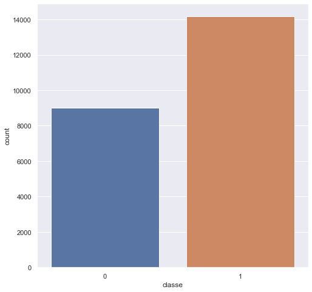

```python
import matplotlib.pyplot as plt
sns.set(font_scale=1.3)
sns.set(rc={'figure.figsize':(8,8)})
ax = sns.countplot(x="classe", data=df_train_noduplicates)
fig = ax.get_figure()
#fig.savefig("balanceamento_Datasets_456.png")
```

```python
y= df_train_noduplicates.classe.to_numpy()
```

```python
y
```

```
array([1, 1, 1, ..., 1, 1, 1], dtype=int64)
```

```python
from collections import Counter
print(Counter(y))
```

```
Counter({1: 14171, 0: 9010})
```

```python
df_train_noduplicates = df_train_noduplicates.drop(['classe'], axis=1)
```

### 1 - Lidando com o desbalanceamento (eliminando artificialmente alguns exemplos da classe majoritaria)

Aqui, utilizei "random under sampling", técnica que permite retirar aleatoriamente dados da classe majoritaria e, assim, balancear os dados

```python
from imblearn.under_sampling import RandomUnderSampler
```

```python
undersample = RandomUnderSampler(sampling_strategy='majority')
```

```python
X_balanced, y_balanced = undersample.fit_resample(df_train_noduplicates, y)
```

```python
from collections import Counter
```

```python
print(Counter(y_balanced))
```

```
Counter({0: 9010, 1: 9010})
```

```python
X_balanced
```

|  | V1 size | V2 size | V3 size | V4 size | V5 size | V6 size | V7 size | V8 size | V9 size | V1 interv. | V2 interv. | V3 interv. | V4 interv. | V5 interv. | V6 interv. | V7 interv. | V8 interv. | V9 interv. |
| --- | --- | --- | --- | --- | --- | --- | --- | --- | --- | --- | --- | --- | --- | --- | --- | --- | --- | --- |
| 0 | 0.007135 | 0.013277 | 0.002182 | 0.002751 | 2.9692 | 9.4991 | 0.074816 | 0.000119 | 0.015014 | 340.48 | 346.470 | 222.0 | 0.0000 | 2.857800 | 6.3813 | 1476 | 222 | 484.530 |
| 1 | 0.167980 | 0.473860 | 0.003874 | 0.005562 | 4.6972 | 23.4240 | 3.183600 | 0.000119 | 0.500520 | 315.01 | 201.400 | 241.0 | 28.1690 | 4.118700 | 19.6590 | 1476 | 222 | 373.350 |
| 2 | 0.100310 | 0.736630 | 0.000345 | 0.000420 | 9.6209 | 91.9940 | 7.372600 | 0.000125 | 0.739770 | 400.63 | 275.310 | 224.0 | 2.9652 | 1.381400 | 0.8520 | 1160 | 222 | 485.330 |
| 3 | 0.689110 | 1.934400 | 0.000215 | 0.000116 | 4.7959 | 29.1920 | 15.070000 | 0.000111 | 2.044300 | 359.96 | 225.750 | 262.5 | 60.0450 | 2.026100 | 3.3624 | 1111 | 222 | 424.290 |
| 4 | 0.039378 | 0.158930 | 0.001014 | 0.001091 | 7.2926 | 58.1530 | 1.432700 | 0.000117 | 0.162960 | 1127.70 | 591.530 | 1588.0 | 11.8610 | -0.590740 | -1.5450 | 1596 | 228 | 1272.100 |
| ... | ... | ... | ... | ... | ... | ... | ... | ... | ... | ... | ... | ... | ... | ... | ... | ... | ... | ... |
| 18015 | 0.005669 | 0.007705 | 0.000805 | 0.001182 | 1.0992 | 2.6555 | 0.022636 | 0.000004 | 0.009534 | 119.37 | 58.795 | 88.0 | 17.7910 | 1.009200 | 2.1254 | 224 | 76 | 132.930 |
| 18016 | 0.002141 | 0.005616 | 0.000030 | 0.000035 | 3.2747 | 13.7110 | 0.031669 | 0.000006 | 0.005984 | 1019.60 | 712.890 | 1606.0 | 5.9304 | -0.446670 | 1.2828 | 1610 | 76 | 1242.000 |
| 18017 | 0.003648 | 0.007715 | 0.000395 | 0.000571 | 2.4083 | 7.4488 | 0.031502 | 0.000002 | 0.008499 | 781.42 | 696.110 | 638.5 | 833.9600 | 0.033527 | 1.0663 | 1590 | 76 | 1044.200 |
| 18018 | 0.002958 | 0.008199 | 0.000125 | 0.000182 | 3.5442 | 16.1860 | 0.050671 | 0.000002 | 0.008678 | 910.68 | 649.120 | 1326.0 | 379.5500 | -0.433940 | 1.3020 | 1610 | 76 | 1116.500 |
| 18019 | 0.000344 | 0.000743 | 0.000131 | 0.000139 | 2.9990 | 7.6233 | 0.003047 | 0.000004 | 0.000815 | 92.40 | 37.420 | 62.0 | 0.0000 | 0.402140 | -1.8565 | 138 | 62 | 99.619 |

18020 rows × 18 columns

```python
X_balanced.describe()
```

|  | V1 size | V2 size | V3 size | V4 size | V5 size | V6 size | V7 size | V8 size | V9 size | V1 interv. | V2 interv. | V3 interv. | V4 interv. | V5 interv. | V6 interv. | V7 interv. | V8 interv. | V9 interv. |
| --- | --- | --- | --- | --- | --- | --- | --- | --- | --- | --- | --- | --- | --- | --- | --- | --- | --- | --- |
| count | 18020.000000 | 18020.000000 | 18020.000000 | 18020.000000 | 18020.000000 | 18020.000000 | 18020.000000 | 18020.000000 | 18020.000000 | 18020.000000 | 18020.000000 | 18020.00000 | 18020.000000 | 18020.000000 | 18020.000000 | 18020.000000 | 18020.000000 | 18020.000000 |
| mean | 0.148816 | 0.877164 | 0.008118 | 0.005586 | 4.050141 | 23.419828 | 7.912367 | 0.000083 | 0.890547 | 763.536421 | 352.779506 | 875.19495 | 95.840536 | -0.526651 | 4.991025 | 1142.252997 | 174.014650 | 859.122735 |
| std | 2.385508 | 21.630522 | 0.508634 | 0.046936 | 2.260812 | 23.755557 | 215.561993 | 0.000137 | 21.653803 | 515.766342 | 260.624493 | 656.92536 | 190.316615 | 2.310512 | 14.631017 | 649.531408 | 154.927482 | 548.965597 |
| min | 0.000056 | 0.000044 | 0.000001 | 0.000000 | -1.931900 | -1.980700 | 0.000245 | 0.000000 | 0.000114 | 64.100000 | 0.200000 | 62.00000 | 0.000000 | -9.702000 | -2.019900 | 68.000000 | 61.000000 | 64.164000 |
| 25% | 0.001424 | 0.002803 | 0.000123 | 0.000079 | 2.355275 | 5.978175 | 0.019074 | 0.000002 | 0.003268 | 126.160000 | 40.705000 | 138.00000 | 0.000000 | -1.140875 | -1.246050 | 224.000000 | 76.000000 | 132.967500 |
| 50% | 0.003453 | 0.008528 | 0.000342 | 0.000187 | 3.527000 | 14.274000 | 0.049861 | 0.000017 | 0.009574 | 875.005000 | 362.160000 | 1190.75000 | 0.000000 | -0.338580 | 1.180250 | 1522.000000 | 153.000000 | 1089.150000 |
| 75% | 0.013145 | 0.029621 | 0.000945 | 0.000882 | 5.520675 | 34.167750 | 0.188942 | 0.000124 | 0.032389 | 1180.225000 | 613.932500 | 1476.00000 | 109.710000 | 0.619560 | 2.503550 | 1610.000000 | 222.000000 | 1309.825000 |
| max | 149.870000 | 1492.400000 | 68.171000 | 3.941900 | 9.849300 | 98.010000 | 14925.000000 | 0.008234 | 1492.500000 | 1675.700000 | 761.070000 | 1676.00000 | 1136.400000 | 9.849400 | 98.010000 | 3468.000000 | 1676.000000 | 1675.700000 |

### Normalização

"A normalização pode ser por amplitude ou por distribuição"

- "Normalização por amplitude: Pode ser por reescala ou por padronização. . A primeira define uma nova escala de valores, limites mínimo e máximo, para todos os atributos. A segunda define um valor central e um valor de espalhamento comuns para todos os atributos."
- Para a normalização por padronização, a cada valor do atributo a ser normalizado é adicionada ou subtraída uma medida de localização e o valor resultante é em seguida multiplicado ou dividido por uma medida de escala. Com isso, diferentes atributos podem ter limites inferiores e superiores distintos, mas terão os mesmos valores para as medidas de escala e espalhamento

### Como decidir qual usar?

Source: https://www.analyticsvidhya.com/blog/2020/04/feature-scaling-machine-learning-normalization-standardization/

### Usando standardization

```python
from sklearn.preprocessing import MinMaxScaler, StandardScaler
scaler = StandardScaler()
Xstd = scaler.fit_transform(X_balanced)
df_balanced_stand = pd.DataFrame(Xstd, columns=X_balanced.columns, index=X_balanced.index)
df_balanced_stand.head()
```

|  | V1 size | V2 size | V3 size | V4 size | V5 size | V6 size | V7 size | V8 size | V9 size | V1 interv. | V2 interv. | V3 interv. | V4 interv. | V5 interv. | V6 interv. | V7 interv. | V8 interv. | V9 interv. |
| --- | --- | --- | --- | --- | --- | --- | --- | --- | --- | --- | --- | --- | --- | --- | --- | --- | --- | --- |
| 0 | -0.059394 | -0.039939 | -0.011670 | -0.060397 | -0.478134 | -0.586015 | -0.036360 | 0.262403 | -0.040434 | -0.820271 | -0.024210 | -0.994349 | -0.503599 | 1.464846 | 0.095025 | 0.513842 | 0.309736 | -0.682380 |
| 1 | 0.008034 | -0.018646 | -0.008344 | -0.000505 | 0.286214 | 0.000176 | -0.021938 | 0.262403 | -0.018012 | -0.869655 | -0.580850 | -0.965426 | -0.355583 | 2.010585 | 1.002554 | 0.513842 | 0.309736 | -0.884912 |
| 2 | -0.020334 | -0.006497 | -0.015281 | -0.110071 | 2.464120 | 2.886738 | -0.002504 | 0.306077 | -0.006963 | -0.703645 | -0.297254 | -0.991304 | -0.488018 | 0.825836 | -0.282902 | 0.027324 | 0.309736 | -0.680923 |
| 3 | 0.226496 | 0.048878 | -0.015537 | -0.116531 | 0.329872 | 0.242989 | 0.033205 | 0.204170 | 0.053283 | -0.782501 | -0.487418 | -0.932696 | -0.188089 | 1.104873 | -0.111316 | -0.048118 | 0.309736 | -0.792117 |
| 4 | -0.045877 | -0.033206 | -0.013966 | -0.095776 | 1.434241 | 1.462148 | -0.030060 | 0.247845 | -0.033602 | 0.706083 | 0.916096 | 1.085093 | -0.441274 | -0.027739 | -0.446736 | 0.698595 | 0.348465 | 0.752303 |

```python
df_balanced_stand.describe()
```

|  | V1 size | V2 size | V3 size | V4 size | V5 size | V6 size | V7 size | V8 size | V9 size | V1 interv. | V2 interv. | V3 interv. | V4 interv. | V5 interv. | V6 interv. | V7 interv. | V8 interv. | V9 interv. |
| --- | --- | --- | --- | --- | --- | --- | --- | --- | --- | --- | --- | --- | --- | --- | --- | --- | --- | --- |
| count | 1.802000e+04 | 1.802000e+04 | 1.802000e+04 | 1.802000e+04 | 1.802000e+04 | 1.802000e+04 | 1.802000e+04 | 1.802000e+04 | 1.802000e+04 | 1.802000e+04 | 1.802000e+04 | 1.802000e+04 | 1.802000e+04 | 1.802000e+04 | 1.802000e+04 | 1.802000e+04 | 1.802000e+04 | 1.802000e+04 |
| mean | -3.113915e-17 | -2.749450e-17 | -3.692400e-17 | 3.618899e-16 | 2.704336e-16 | 3.003886e-16 | 5.040363e-17 | -9.443088e-15 | -5.351997e-17 | 1.423451e-16 | 5.926570e-16 | 5.304623e-15 | 5.519330e-15 | -1.019215e-15 | -6.993727e-17 | -4.016346e-15 | -5.592679e-14 | 3.149152e-15 |
| std | 1.000028e+00 | 1.000028e+00 | 1.000028e+00 | 1.000028e+00 | 1.000028e+00 | 1.000028e+00 | 1.000028e+00 | 1.000028e+00 | 1.000028e+00 | 1.000028e+00 | 1.000028e+00 | 1.000028e+00 | 1.000028e+00 | 1.000028e+00 | 1.000028e+00 | 1.000028e+00 | 1.000028e+00 | 1.000028e+00 |
| min | -6.236141e-02 | -4.055125e-02 | -1.595791e-02 | -1.190104e-01 | -2.646044e+00 | -1.069275e+00 | -3.670564e-02 | -6.038010e-01 | -4.112250e-02 | -1.356149e+00 | -1.352863e+00 | -1.237915e+00 | -5.035987e-01 | -3.971243e+00 | -4.791956e-01 | -1.653935e+00 | -7.294883e-01 | -1.448143e+00 |
| 25% | -6.178827e-02 | -4.042371e-02 | -1.571706e-02 | -1.173362e-01 | -7.496924e-01 | -7.342340e-01 | -3.661829e-02 | -5.876325e-01 | -4.097680e-02 | -1.235820e+00 | -1.197444e+00 | -1.122221e+00 | -5.035987e-01 | -2.658464e-01 | -4.263031e-01 | -1.413755e+00 | -6.326661e-01 | -1.322807e+00 |
| 50% | -6.093737e-02 | -4.015902e-02 | -1.528845e-02 | -1.150168e-01 | -2.314018e-01 | -3.850081e-01 | -3.647546e-02 | -4.780122e-01 | -4.068561e-02 | 2.161282e-01 | 3.599337e-02 | 4.803648e-01 | -5.035987e-01 | 8.140019e-02 | -2.604659e-01 | 5.846639e-01 | -1.356456e-01 | 4.190311e-01 |
| 75% | -5.687433e-02 | -3.918383e-02 | -1.410288e-02 | -1.002151e-01 | 6.504629e-01 | 4.524508e-01 | -3.583024e-02 | 2.987977e-01 | -3.963193e-02 | 8.079243e-01 | 1.002056e+00 | 9.145966e-01 | 7.287776e-02 | 4.960990e-01 | -1.700185e-01 | 7.201499e-01 | 3.097364e-01 | 8.210255e-01 |
| max | 6.276456e+01 | 6.895646e+01 | 1.340155e+02 | 8.386817e+01 | 2.565149e+00 | 3.139991e+00 | 6.920284e+01 | 5.933166e+01 | 6.888632e+01 | 1.768609e+00 | 1.566629e+00 | 1.219054e+00 | 5.467669e+00 | 4.490927e+00 | 6.357832e+00 | 3.580753e+00 | 9.695033e+00 | 1.487525e+00 |

## Seleção de atributos

### Mutual information test

- OBS.: Advantage of using mutual information over F-Test is, it does well with the non-linear relationship between feature and target variable.

Mutual Information between two variables measures the dependence of one variable to another. If X and Y are two variables, and If X and Y are independent, then no information about Y can be obtained by knowing X or vice versa. Hence their mutual information is 0. If X is a deterministic function of Y, then we can determine X from Y and Y from X with mutual information 1. When we have Y = f(X,Z,M,N), 0 < mutual information < 1 We can select our features from feature space by ranking their mutual information with the target variable.

Source: https://towardsdatascience.com/why-how-and-when-to-apply-feature-selection-e9c69adfabf2

```
Feature 0: 0.364637
Feature 1: 0.352392
Feature 2: 0.459893
Feature 3: 0.244411
Feature 4: 0.105827
Feature 5: 0.104798
Feature 6: 0.418850
Feature 7: 0.672584
Feature 8: 0.367363
Feature 9: 0.510031
Feature 10: 0.454374
Feature 11: 0.608733
Feature 12: 0.118026
Feature 13: 0.336301
Feature 14: 0.417558
Feature 15: 0.668015
Feature 16: 0.693313
Feature 17: 0.485004
```

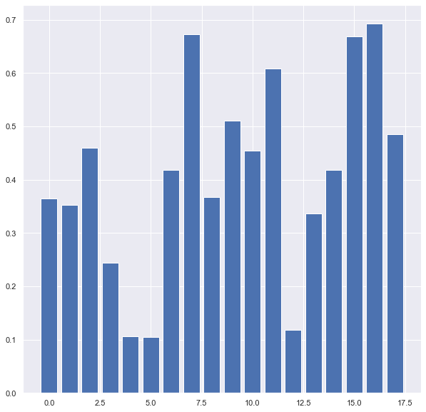

```python
from pandas import read_csv
from sklearn.model_selection import train_test_split
from sklearn.feature_selection import SelectKBest
from sklearn.feature_selection import mutual_info_classif
from matplotlib import pyplot

# feature selection
def select_features(X_train, y_train, X_test):
	# configure to select all features
	fs = SelectKBest(score_func=mutual_info_classif, k='all')
	# learn relationship from training data
	fs.fit(X_train, y_train)
	# transform train input data
	X_train_fs = fs.transform(X_train)
	# transform test input data
	X_test_fs = fs.transform(X_test)
	return X_train_fs, X_test_fs, fs

# load the dataset
X = df_balanced_stand
y = y_balanced

# split into train and test sets
X_train, X_test, y_train, y_test = train_test_split(X, y, test_size=0.33, random_state=1)
# feature selection
X_train_fs, X_test_fs, fs = select_features(X_train, y_train, X_test)
# what are scores for the features
for i in range(len(fs.scores_)):
	print('Feature %d: %f' % (i, fs.scores_[i]))
# plot the scores
pyplot.bar([i for i in range(len(fs.scores_))], fs.scores_)
pyplot.show()
```

### ANOVA f-test

```
Feature 0: 50.325007
Feature 1: 21.767162
Feature 2: 2.680583
Feature 3: 114.197534
Feature 4: 1325.712541
Feature 5: 841.581608
Feature 6: 17.271606
Feature 7: 10618.276717
Feature 8: 22.467599
Feature 9: 4405.862593
Feature 10: 79.835717
Feature 11: 1191.053498
Feature 12: 184.262389
Feature 13: 492.248914
Feature 14: 1241.172776
Feature 15: 3888.375839
Feature 16: 9833.816048
Feature 17: 3470.793700
```

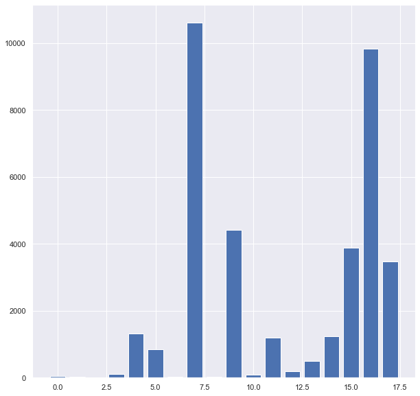

```python
# example of anova f-test feature selection for numerical data
from pandas import read_csv
from sklearn.model_selection import train_test_split
from sklearn.feature_selection import SelectKBest
from sklearn.feature_selection import f_classif
from matplotlib import pyplot

def select_features(X_train, y_train, X_test):
	# configure to select all features
	fs = SelectKBest(score_func=f_classif, k='all')
	# learn relationship from training data
	fs.fit(X_train, y_train)
	# transform train input data
	X_train_fs = fs.transform(X_train)
	# transform test input data
	X_test_fs = fs.transform(X_test)
	return X_train_fs, X_test_fs, fs

X_train, X_test, y_train, y_test = train_test_split(df_balanced_stand, y_balanced, test_size=0.33, random_state=1)
# feature selection
X_train_fs, X_test_fs, fs = select_features(X_train, y_train, X_test)
# what are scores for the features
for i in range(len(fs.scores_)):
	print('Feature %d: %f' % (i, fs.scores_[i]))
# plot the scores
pyplot.bar([i for i in range(len(fs.scores_))], fs.scores_)
pyplot.show()
```

### Gerando um csv com os dados pre processados:

```python
len(df_balanced_stand)
```

```
18020
```

```python
df_balanced_stand.head()
```

|  | V1 size | V2 size | V3 size | V4 size | V5 size | V6 size | V7 size | V8 size | V9 size | V1 interv. | V2 interv. | V3 interv. | V4 interv. | V5 interv. | V6 interv. | V7 interv. | V8 interv. | V9 interv. |
| --- | --- | --- | --- | --- | --- | --- | --- | --- | --- | --- | --- | --- | --- | --- | --- | --- | --- | --- |
| 0 | -0.059394 | -0.039939 | -0.011670 | -0.060397 | -0.478134 | -0.586015 | -0.036360 | 0.262403 | -0.040434 | -0.820271 | -0.024210 | -0.994349 | -0.503599 | 1.464846 | 0.095025 | 0.513842 | 0.309736 | -0.682380 |
| 1 | 0.008034 | -0.018646 | -0.008344 | -0.000505 | 0.286214 | 0.000176 | -0.021938 | 0.262403 | -0.018012 | -0.869655 | -0.580850 | -0.965426 | -0.355583 | 2.010585 | 1.002554 | 0.513842 | 0.309736 | -0.884912 |
| 2 | -0.020334 | -0.006497 | -0.015281 | -0.110071 | 2.464120 | 2.886738 | -0.002504 | 0.306077 | -0.006963 | -0.703645 | -0.297254 | -0.991304 | -0.488018 | 0.825836 | -0.282902 | 0.027324 | 0.309736 | -0.680923 |
| 3 | 0.226496 | 0.048878 | -0.015537 | -0.116531 | 0.329872 | 0.242989 | 0.033205 | 0.204170 | 0.053283 | -0.782501 | -0.487418 | -0.932696 | -0.188089 | 1.104873 | -0.111316 | -0.048118 | 0.309736 | -0.792117 |
| 4 | -0.045877 | -0.033206 | -0.013966 | -0.095776 | 1.434241 | 1.462148 | -0.030060 | 0.247845 | -0.033602 | 0.706083 | 0.916096 | 1.085093 | -0.441274 | -0.027739 | -0.446736 | 0.698595 | 0.348465 | 0.752303 |

```python
df_final1 = df_balanced_stand.drop(['V2 size'], axis=1)
```

```python
df_final2 = df_final1.drop(['V3 size'], axis=1)
```

```python
df_final3 = df_final2.drop(['V6 size'], axis=1)
```

```python
df_final4 = df_final3.drop(['V7 size'], axis=1)
```

```python
df_final5 = df_final4.drop(['V9 size'], axis=1)
```

```python
df_final6 = df_final5.drop(['V2 interv.'], axis=1)
```

```python
df_final7 = df_final6.drop(['V4 interv.'], axis=1)
```

```python
df_final8 = df_final7.drop(['V5 interv.'], axis=1)
```

```python
df_final8.head()
```

|  | V1 size | V4 size | V5 size | V8 size | V1 interv. | V3 interv. | V6 interv. | V7 interv. | V8 interv. | V9 interv. |
| --- | --- | --- | --- | --- | --- | --- | --- | --- | --- | --- |
| 0 | -0.059394 | -0.060397 | -0.478134 | 0.262403 | -0.820271 | -0.994349 | 0.095025 | 0.513842 | 0.309736 | -0.682380 |
| 1 | 0.008034 | -0.000505 | 0.286214 | 0.262403 | -0.869655 | -0.965426 | 1.002554 | 0.513842 | 0.309736 | -0.884912 |
| 2 | -0.020334 | -0.110071 | 2.464120 | 0.306077 | -0.703645 | -0.991304 | -0.282902 | 0.027324 | 0.309736 | -0.680923 |
| 3 | 0.226496 | -0.116531 | 0.329872 | 0.204170 | -0.782501 | -0.932696 | -0.111316 | -0.048118 | 0.309736 | -0.792117 |
| 4 | -0.045877 | -0.095776 | 1.434241 | 0.247845 | 0.706083 | 1.085093 | -0.446736 | 0.698595 | 0.348465 | 0.752303 |

```python
df_final8.shape
```

```
(18020, 10)
```

```python
df_final8.to_csv("preprocessed_data.csv", index=False)
```